# Adverse effect of bexaroten therapy in T-lymphom

###### First Systemic Therapy

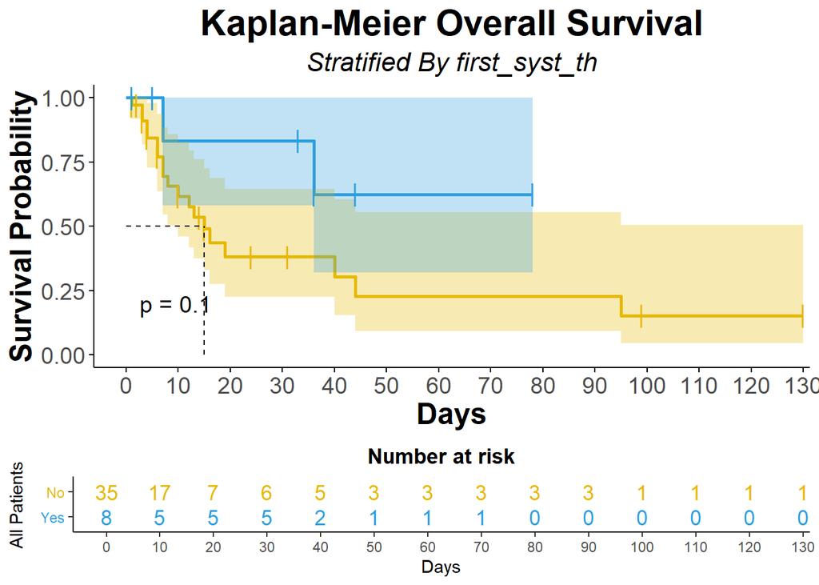

```r
res_surv_response$surv[[2]]$`KM stratified`
```

###### AE Grade 3-4

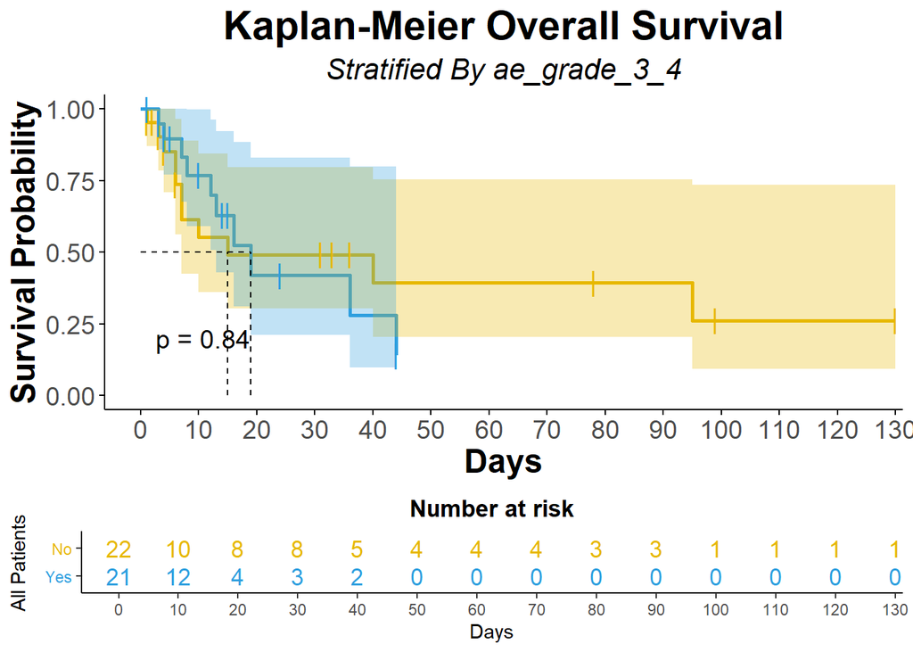

```r
res_surv_response$surv[[3]]$`KM stratified`
```

###### Monotherapy

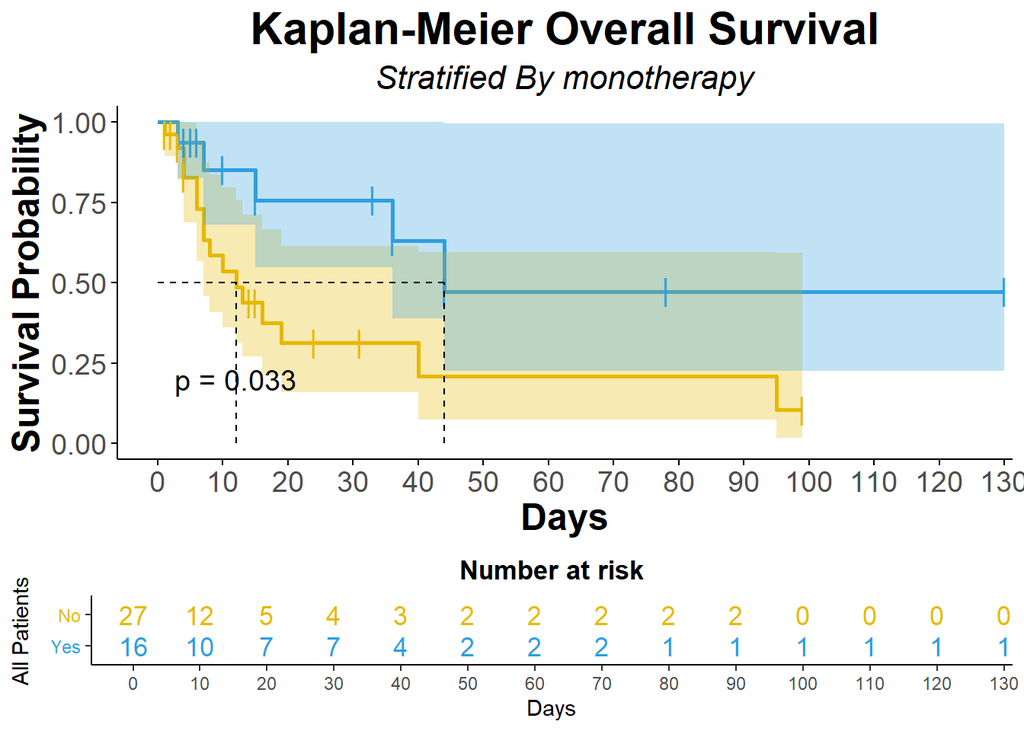

```r
res_surv_response$surv[[4]]$`KM stratified`
```

###### Gender

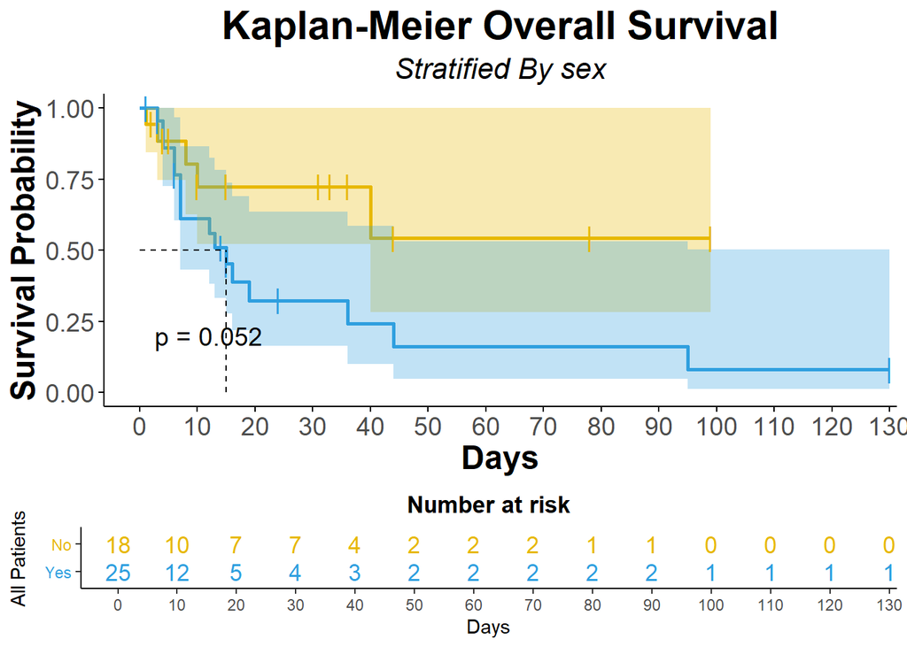

```r
res_surv_response$surv[[5]]$`KM stratified`
```

###### BMI

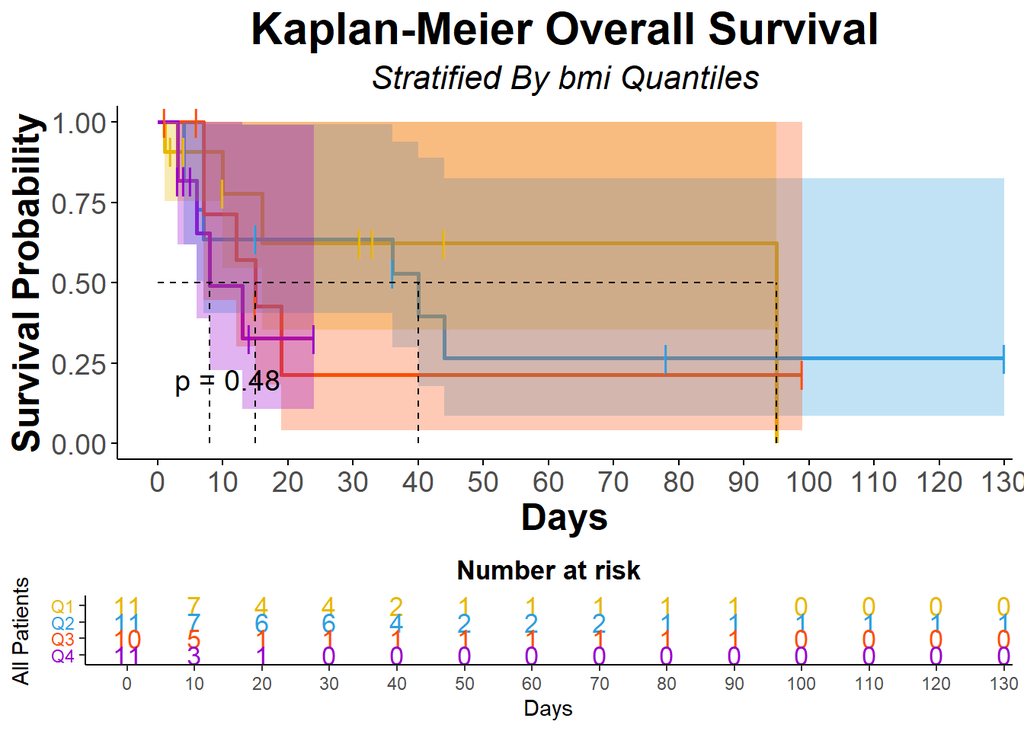

```r
res_surv_response$surv[[6]]$`KM stratified`
```

###### Age

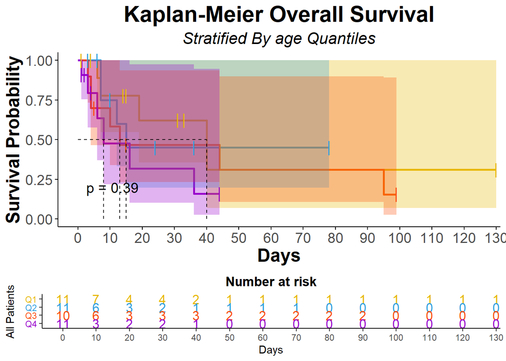

```r
res_surv_response$surv[[7]]$`KM stratified`
```

##### Cox Proportional Hazards

*Cox PH Table Output*

A standard Cox PH results table typically includes:  
- **Hazard Ratio (HR):** The estimated relative risk per unit change (or category) in each covariate.  
- **95% Confidence Interval (CI):** Lower and upper bounds for the HR, indicating precision.  
- **p-value:** Significance of the association between each covariate and the hazard.

*Cox PH Plot*

To visualize model-based survival differences you can use: - **Dichotomous variable plot:** Two survival curves (e.g., exposed vs. unexposed), annotated with HR and p-value from the Cox model.  
- **Quartile-based plot:** Split a continuous covariate into four quantiles (Q1–Q4) and plot four Kaplan–Meier curves to illustrate dose–response patterns.

*Forest Plot for Quartile-Based Analysis*

A forest plot for a continuous covariate divided into quartiles displays: - **Quartile labels (Q1–Q4):** Listed on the vertical axis, with Q1 usually as the reference.  
- **Point estimates and CIs:** Horizontal lines and markers showing the HR ± 95% CI for each quartile relative to Q1.  
- **Trend p-value (optional):** Overall test for trend across quartiles, if desired.

###### PS-ECOG

```r
res_surv_response$surv[[1]]$`CoxPH print table`
```

| **Characteristic** | **HR** | **95% CI** | **p-value** |
| --- | --- | --- | --- |
| ps_ecog | 1.30 | 0.54, 3.14 | 0.6 |

Abbreviations: CI = Confidence Interval, HR = Hazard Ratio

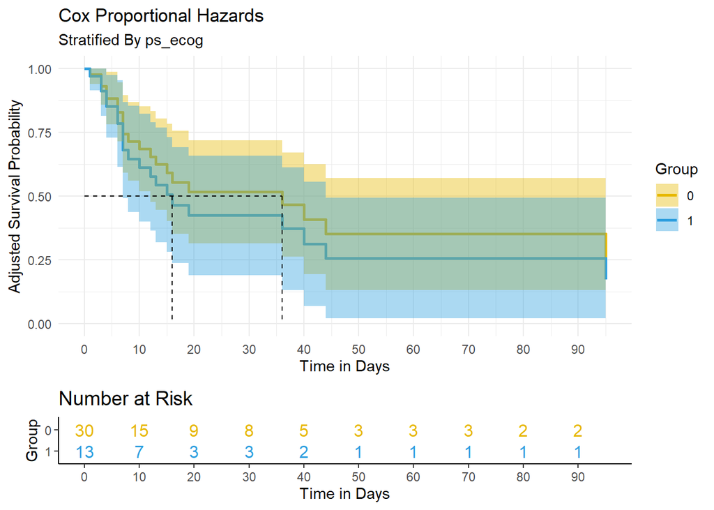

```r
res_surv_response$surv[[1]]$`CoxPH plot`
```

###### First Systemic Therapy

```r
res_surv_response$surv[[2]]$`CoxPH print table`
```

| **Characteristic** | **HR** | **95% CI** | **p-value** |
| --- | --- | --- | --- |
| first_syst_th | 0.32 | 0.07, 1.38 | 0.12 |

Abbreviations: CI = Confidence Interval, HR = Hazard Ratio

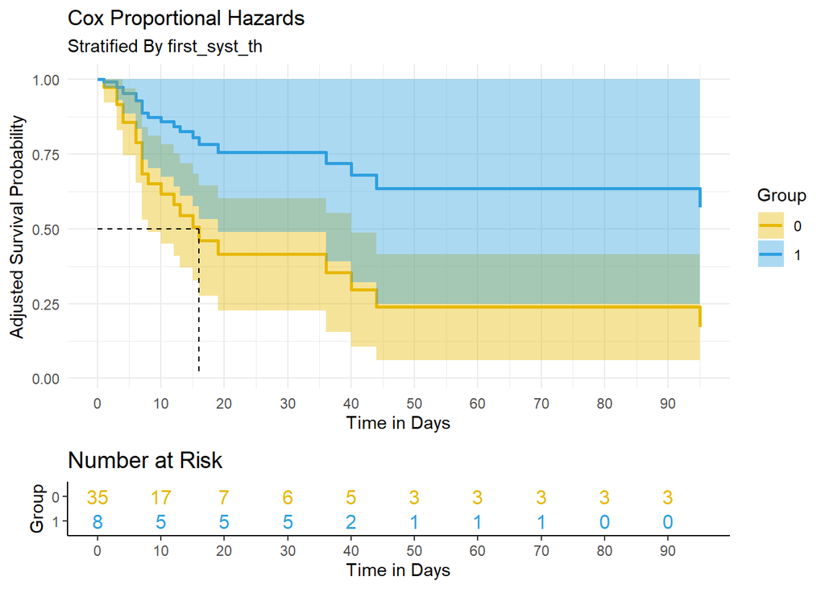

```r
res_surv_response$surv[[2]]$`CoxPH plot`
```

###### AE Grade 3-4

```r
res_surv_response$surv[[3]]$`CoxPH print table`
```

| **Characteristic** | **HR** | **95% CI** | **p-value** |
| --- | --- | --- | --- |
| ae_grade_3_4 | 1.09 | 0.45, 2.64 | 0.9 |

Abbreviations: CI = Confidence Interval, HR = Hazard Ratio

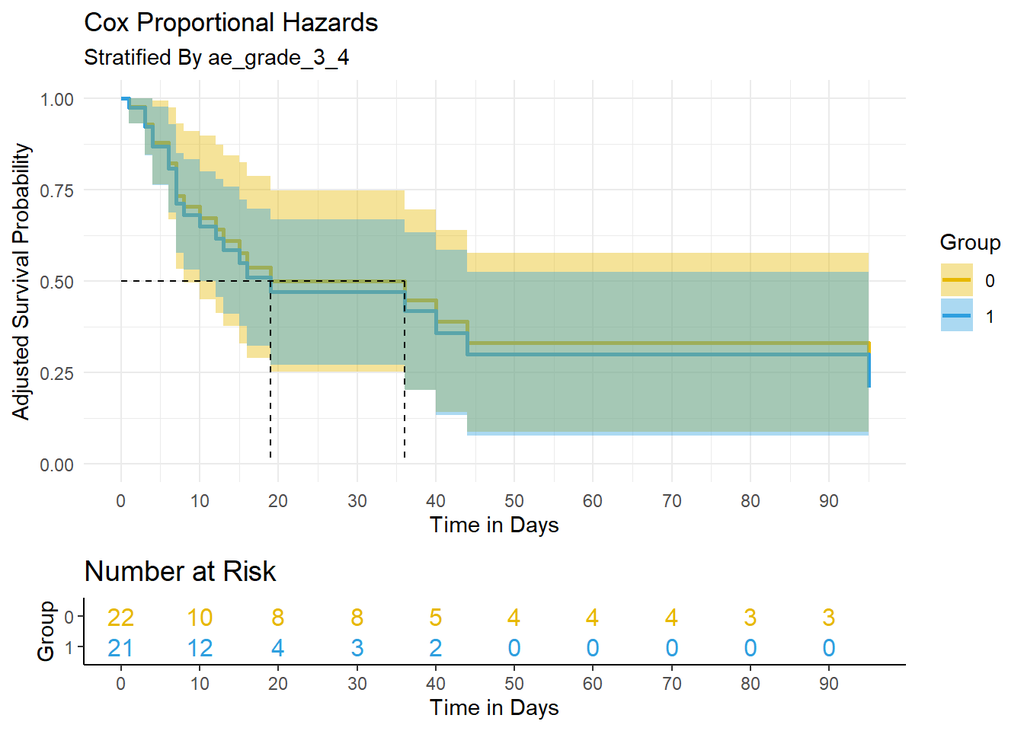

```r
res_surv_response$surv[[3]]$`CoxPH plot`
```

###### Monotherapy

```r
res_surv_response$surv[[4]]$`CoxPH print table`
```

| **Characteristic** | **HR** | **95% CI** | **p-value** |
| --- | --- | --- | --- |
| monotherapy | 0.35 | 0.13, 0.96 | 0.041 |

Abbreviations: CI = Confidence Interval, HR = Hazard Ratio

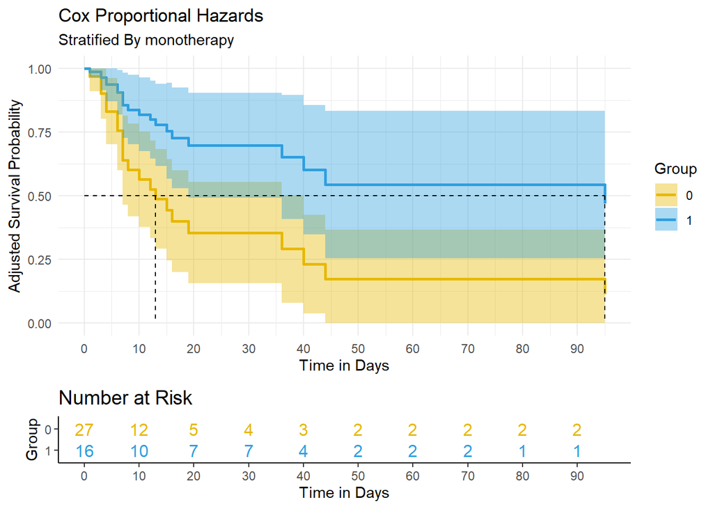

```r
res_surv_response$surv[[4]]$`CoxPH plot`
```

###### Gender

```r
res_surv_response$surv[[5]]$`CoxPH print table`
```

| **Characteristic** | **HR** | **95% CI** | **p-value** |
| --- | --- | --- | --- |
| sex | 2.64 | 0.96, 7.23 | 0.060 |

Abbreviations: CI = Confidence Interval, HR = Hazard Ratio

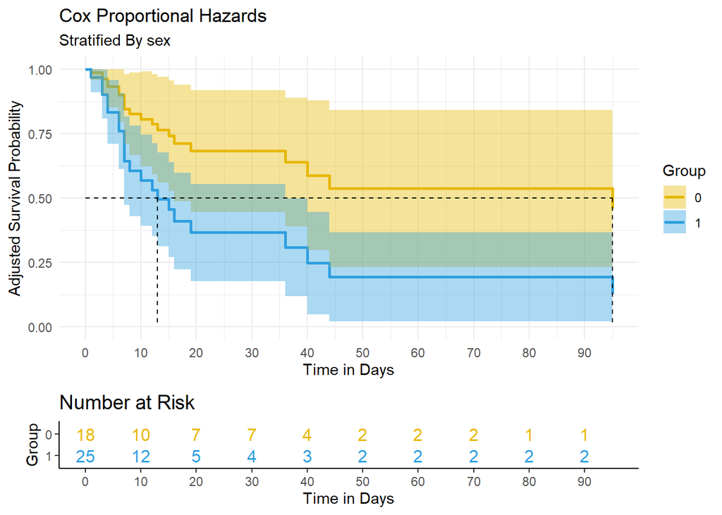

```r
res_surv_response$surv[[5]]$`CoxPH plot`
```

###### BMI

```r
res_surv_response$surv[[6]]$`CoxPH print table`
```

| **Characteristic** | **HR** | **95% CI** | **p-value** |
| --- | --- | --- | --- |
| bmi | 1.06 | 0.98, 1.15 | 0.13 |

Abbreviations: CI = Confidence Interval, HR = Hazard Ratio

```r
res_surv_response$surv[[6]]$`CoxPH plot`
```

[output not shown]

```r
res_surv_response$surv[[6]]$`CoxPH forest plot`
```

[output not shown]

###### Age

```r
res_surv_response$surv[[7]]$`CoxPH print table`
```

| **Characteristic** | **HR** | **95% CI** | **p-value** |
| --- | --- | --- | --- |
| age | 1.04 | 1.00, 1.08 | 0.078 |

Abbreviations: CI = Confidence Interval, HR = Hazard Ratio

```r
res_surv_response$surv[[7]]$`CoxPH plot`
```

[output not shown]

```r
res_surv_response$surv[[7]]$`CoxPH forest plot`
```

[output not shown]

### 5.3.3 Linear regression

#### 5.3.3.1 Time to response

Linear regression was identified as the most suitable model for the non-zero subset of the *Time to response* variable, based on residual analysis. The table below shows that none of the tested independent variables had a statistically significant association with $response\_time\_to$.

**The model equation:**
$$\begin{aligned}
\operatorname{Time to response} &= \alpha +
\beta_{1}(\operatorname{independent variable}) + \epsilon\\
\varepsilon_i &\sim \mathcal{N}(0,\,\sigma^2)
\end{aligned}$$

```r
res_timeTOeffect <- d04 |>
  select(response_time_to, all_of(variab_indep_02)) |>
  mutate(sex = if_else(sex == "M",1,0)) |>
  pivot_longer(cols = -response_time_to,
               names_to = "indep_name",
               values_to = "indep_value") |>
  group_by(indep_name) |>
  nest() |>
  mutate(mod = map(data, ~lm(data = .x, response_time_to ~ indep_value)),
         tidier = map(mod, ~tidy(.x, conf.int = T)),
         qqplot = map2(mod, indep_name, ~ggqqplot(na.omit(resid(.x)) |> as_tibble(),
                                                  x = "value", title = .y)
                       ))


res_timeTOeffect_tab <- res_timeTOeffect|>
  unnest(tidier) |>
  filter(term == "indep_value") |>
  select(-(data:term), -qqplot)


res_timeTOeffect_tab |>
  select(-std.error, - statistic) |>
  kable(col.names = c("Independent", "Estimate", "p-value",
                      "5% CI", "95% CI"),
        digits = 3) |>
  kable_styling(
    full_width = F,
    latex_options = c(
      "hold_position" # stop table floating
    ),
    bootstrap_options = c("striped", "hover", "condensed", "responsive")
  ) %>%
  collapse_rows(columns = 1, valign = "top")
```

| Independent | Estimate | p-value | 5% CI | 95% CI |
| --- | --- | --- | --- | --- |
| age | -0.020 | 0.570 | -0.090 | 0.050 |
| sex | -0.321 | 0.725 | -2.147 | 1.506 |
| bmi | 0.116 | 0.154 | -0.045 | 0.276 |
| ps_ecog | 0.087 | 0.930 | -1.884 | 2.058 |
| first_syst_th | -0.889 | 0.443 | -3.204 | 1.426 |
| ae_grade_3_4 | -0.136 | 0.879 | -1.934 | 1.662 |
| monotherapy | -0.652 | 0.483 | -2.510 | 1.207 |

# 6 Conclussion

In summary, this analysis highlights key factors influencing both the tolerability and efficacy of bexarotene treatment in patients with T-lymphoma. Logistic regression revealed that monotherapy was associated with treatment discontinuation due to adverse events, while BMI influenced the occurrence of high-grade hypertriglyceridemia. Regarding treatment efficacy, early-stage disease was more likely in patients receiving first-line systemic therapy and those on monotherapy. However, no significant predictors were identified for time to response in the linear model. These findings can inform clinical decision-making regarding patient selection and risk stratification during bexarotene therapy.

# 7 Session info

**Platform**

```r
df_session_platform <- devtools::session_info()$platform %>%
  unlist(.) %>%
  as.data.frame(.) %>%
  rownames_to_column(.)

colnames(df_session_platform) <- c("Setting", "Value")

kable(
  df_session_platform,
  booktabs = T,
  align = "l",
  caption = "(ref:Reproducibility-SessionInfo-R-environment-title)", # complete caption for main document
  caption.short = " " # "(ref:Reproducibility-SessionInfo-R-environment-caption)" # short caption for LoT
) %>%
  kable_styling(full_width = F,
                latex_options = c(
                  "hold_position" # stop table floating
                ),
                bootstrap_options = c("striped", "hover", "condensed", "responsive")
  )
```

[output not shown]

**Used packages**

```r
subset(data.frame(sessioninfo::package_info()), attached==TRUE, c(package, loadedversion, date))
```

|  | package | loadedversion | date |
| --- | --- | --- | --- |
| adjustedCurves | adjustedCurves | 0.11.2 | 2024-07-29 |
| bayestestR | bayestestR | 0.15.3 | 2025-04-28 |
| broom | broom | 1.0.8 | 2025-03-28 |
| car | car | 3.1-3 | 2024-09-27 |
| carData | carData | 3.0-5 | 2022-01-06 |
| correlation | correlation | 0.8.7 | 2025-03-03 |
| corrr | corrr | 0.4.4 | 2022-08-16 |
| datawizard | datawizard | 1.0.2 | 2025-03-24 |
| dials | dials | 1.4.0 | 2025-02-13 |
| dplyr | dplyr | 1.1.4 | 2023-11-17 |

[output cut: 54 more lines]